# Working with NEON Site Management Data

This tutorial will guide you through accessing, navigating, and working with the NEON data product Site management and event reporting (DP1.10111.001), including how to use code tools in the `neonUtilities`,`geoNEON`, and `neonSiteMgmtEventData` R packages designed specifically for this data product.

If you are new to using NEON data, we recommend first following the [Download and Explore](https://www.neonscience.org/resources/learning-hub/tutorials/download-explore-neon-data) tutorial to get familiar with NEON data formats and the `neonUtilities` package.

## Objectives

After completing this activity, you will be able to:

- Download site event data by site or by event type
- Access data related to the spatial extent of an event
- Understand the metadata associated with site events
- Summarize the event data by combinations of site, year, and event type
- Create and export polygons to represent the spatial extent of unique event types

## Things You’ll Need To Complete This Tutorial

To complete this tutorial, you will need a version of R (4.0 or higher) and, preferably, RStudio loaded on your computer. This code may work with earlier versions but it hasn’t been tested.

### Install R Packages

- **neonUtilities:** `install.packages("neonUtilities")`
- **pak:** `install.packages("pak")`
- **geoNEON:** `pak::pak("NEONScience/NEON-geolocation/geoNEON")`
- **neonSiteMgmtEventData:** `pak::pak("NEONScience/neonSiteMgmtEventData")`

## Additional Resources

- Site management and event reporting [details page](https://data.neonscience.org/data-products/DP1.10111.001)

## Site management and event reporting: Background

Events often occur at NEON sites that have an impact on the local ecosystems, but that are not specifically captured in scheduled and planned NEON data collection. These events may be planned or unplanned - for example, controlled burns, wildfires, grazing rotations, and hurricanes. The Site management and event reporting data product is designed to record information about these events. Data are recorded on an ad hoc basis, driven by the occurrence of relevant events.

#### Event duration and recording

In order to match the publication model for NEON data products and to ensure events are published as quickly as possible, site management and event reporting data are recorded in one-month intervals. This means events longer than one month will have multiple data records for one `eventID`. The `eventID`, which includes the site code, original start date, and event type, will remain the same for all records related to the same event. The original start date embedded in the `eventID` compared to the `startDate` field for the record indicates if there are related records for previous months. The `ongoingEvent` field indicates if a record for the next subsequent month is expected.

Date uncertainty is captured in a record’s `estimatedOrActualDate` field. If the date is `estimated` additional comments are recorded in the `dateRemarks` field. The start and end date range includes any date uncertainty.

## Set up R environment

First install and load the necessary packages. Skip the install step if packages are already installed, and modify the working directory file path for your computer.

As of June 2026, NEON requires an API token for data downloads, to reduce bot scraping and improve user support. Tokens can be generated in NEON data portal user accounts - log in to your account or create one, and go to the API Tokens section. For best practices in storing and using tokens, follow the instructions [here](https://www.neonscience.org/resources/learning-hub/tutorials/api-token-setup). This tutorial assumes your token is stored as an environment variable named `NEON_TOKEN`, as demonstrated in the linked tutorial. Modify token retrieval code as needed if your token is stored differently.

```r
install.packages("neonUtilities")
install.packages("devtools")
pak::pak("NEONScience/NEON-geolocation/geoNEON")
pak::pak("NEONScience/neonSiteMgmtEventData")
install.packages("ggplot2")
install.packages("dplyr")
install.packages("stringr")
install.packages("tidyr")
install.packages("lubridate")
install.packages("terra")
install.packages("sf")
install.packages("leaflet")
install.packages("magrittr")
install.packages("tidyselect")
install.packages("tibble")

library(neonUtilities)
library(geoNEON)
library(neonSiteMgmtEventData)
library(ggplot2)
library(dplyr)
library(stringr)
library(tidyr)
library(lubridate)
library(terra)
library(sf)
library(leaflet)
library(magrittr)
library(tidyselect)
library(tibble)

setwd("~/data")
token <- Sys.getenv("NEON_TOKEN")
```

## Downloading event data: All events at a site

The simplest way to access site event data is to download all the events for a particular site. Let’s check out events at Lower Teakettle (TEAK) in California. We’ll use `include.provisional=T` to get events up to the present.

```r
events <- loadByProduct(dpID="DP1.10111.001",
                        site="TEAK",
                        check.size=F,
                        include.provisional=T,
                        token=token)
```

The download includes the usual metadata files associated with NEON data, and two data tables: `sim_eventData` and `sim_locationVisitsAndAttributes`.

The `sim_locationVisitsAndAttributes` table provides a summary of annual visit totals, environmental context, and mitigation actions by location to support estimates of NEON sampling impact and location vulnerability. For TEAK, and all other terrestrial sites, each `namedLocation` has a record per year for the total unique visits per sampling location. Additional fields describe environmental context (slope, soilOrder, land cover type), document location-specific mitigation measures (such as boardwalks or geoblocks used to minimize trampling), and report the number of sampling events that were cancelled because the location was deemed too vulnerable. Currently, TEAK has no additional mitigation structures, and one sampling bout at TEAK_013 was cancelled in 2025 due to vulnerability. At aquatic sites the total number of visits per site per year is reported, and more specific environmental context fields are not provided.

Let’s take a closer look at `sim_eventData` which documents the external disturbance events.

```r
list2env(events, .GlobalEnv)
```

```
## <environment: R_GlobalEnv>
```

```r
head(sim_eventData)
```

```
##                                    uid domainID siteID namedLocation locationID
## 1 2a34be0f-2cb1-4938-8aed-105b6e8b2370      D17   TEAK          TEAK       TEAK
## 2 49424b80-bdf1-41ed-9b18-5f34085d5d55      D17   TEAK          TEAK       TEAK
## 3 b28e62bd-76a1-4654-9e1a-8dfd04b611e7      D17   TEAK          TEAK       TEAK
## 4 07ae2dab-6622-47a2-9410-0bb4a7a6cff6      D17   TEAK          TEAK       TEAK
## 5 cba1abc5-e6b0-4cd4-b394-ce14f662d295      D17   TEAK          TEAK       TEAK
## 6 a63e2562-4779-4b63-92ac-d7b2653e14c0      D17   TEAK          TEAK       TEAK
##    startDate    endDate ongoingEvent estimatedOrActualDate dateRemarks
## 1 2017-05-01 2017-05-31            Y                actual        <NA>
## 2 2017-05-31 2017-06-30            Y                actual        <NA>
## 3 2017-06-30 2017-07-30            Y                actual        <NA>
## 4 2017-07-30 2017-08-29            Y                actual        <NA>
## 5 2017-08-29 2017-09-28            Y                actual        <NA>
## 6 2017-10-28 2017-11-27            Y                actual        <NA>
##                 eventID samplingProtocolVersion eventType methodTypeChoice name
```

[output cut: 34 more lines]

Let’s first check out the types of events recorded.

```r
sim_eventData |>
  select(eventType, methodTypeChoice) |>
  unique()
```

```
##               eventType    methodTypeChoice
## 1               grazing             grazing
## 32  wildlifeDisturbance wildlifeDisturbance
## 59          obstruction         obstruction
## 111                fire       fire-wildfire
```

TEAK is a managed site, so the events recorded include both acts of nature and active management by the site hosts (grazing).

The `neonSiteMgmtEventData` package provides a `summarizeSIM()` function that provides 3 summary tables by site; site and eventType; and site, eventType, and year.

```r
summarizeSIM(df= sim_eventData)
```

```
## Sites:  All Sites
## Event Type:  All Event Types
```

```
## $summary
##   totalRecords uniqueEvents uniqueEventTypes
## 1          117            4                4
##
## $eventTypeTable
##             eventType TEAK Total
## 1                fire    1     1
## 2             grazing    1     1
## 3         obstruction    1     1
## 4 wildlifeDisturbance    1     1
##
## $yearlyEventTypeTable
##    years           eventType TEAK TotalUniqueEvents
## 1   2017             grazing    1                 1
## 2   2018             grazing    1                 1
## 3   2019             grazing    1                 1
## 4   2019 wildlifeDisturbance    1                 1
## 5   2020             grazing    1                 1
## 6   2021             grazing    1                 1
## 7   2021         obstruction    1                 1
## 8   2022             grazing    1                 1
## 9   2022         obstruction    1                 1
## 10  2023             grazing    1                 1
## 11  2024             grazing    1                 1
## 12  2025                fire    1                 1
## 13  2025             grazing    1                 1
## 14  2026             grazing    1                 1
```

The `$summary` table sums the number of records in the input dataframe and summarizes the number of individual records, unique events (since a event that is longer than one month will have multiple records), and unique event types.

Next, the `$eventTypeTable` counts the number of unique eventIDs by eventType and site. The `$yearlyEventTypeTable` includes grouping by year as well. At TEAK, there are over 100 records but most correspond to a long term grazing event.

There is one wildfire reported. When we look at an event like a fire, we probably want to know exactly where this happened - which NEON sampling areas were burned?

## Finding the spatial extent of an event

How to approach the spatial distribution of an event depends on your scientific question. If you’re working with data from NEON sampling plots, you might just want to know which plots are affected. You can find that information in the `locationID` field, which contains either one location or a comma-delimited list of locations for each record. Let’s look at the locations associated with the fire in 2025.

```r
burn <- sim_eventData |>
  filter(methodTypeChoice=="fire-wildfire")

burn.locs <- burn |>
  select(locationID) |>
  unlist() |>
  str_split(",") |>
  unlist() |>
  trimws() |>
  unique()

burn.locs
```

```
##  [1] "TEAK_001.basePlot.all"      "TEAK_002.basePlot.all"
##  [3] "TEAK_003.basePlot.all"      "TEAK_006.basePlot.all"
##  [5] "TEAK_007.basePlot.all"      "TEAK_013.basePlot.all"
##  [7] "TEAK_015.basePlot.all"      "TEAK_017.basePlot.all"
##  [9] "TEAK_018.basePlot.all"      "TEAK_019.basePlot.all"
## [11] "TEAK_021.basePlot.all"      "TEAK_024.basePlot.all"
## [13] "TEAK_025.basePlot.all"      "TEAK_001.tickPlot.tck"
## [15] "TEAK_002.tickPlot.tck"      "TEAK_006.tickPlot.tck"
## [17] "TEAK_025.tickPlot.tck"      "TEAK_001.mammalGrid.mam"
## [19] "TEAK_007.mammalGrid.mam"    "TEAK_025.mammalGrid.mam"
## [21] "TEAK_001.birdGrid.brd"      "TEAK_006.birdGrid.brd"
## [23] "TEAK_007.birdGrid.brd"      "TEAK_031.birdGrid.brd"
## [25] "TEAK_038.mosquitoPoint.mos" "TEAK_039.mosquitoPoint.mos"
## [27] "TEAK_041.mosquitoPoint.mos"
```

Now we have a list of NEON named locations. We can see if the plot(s) we are working with are on the list, and proceed accordingly.

But what if we’re interested in a broader picture, and we want to get a sense of the overall burned area?

Below, we’ll find spatial data associated with point locations of disturbance events and create a polygon to export as an sf object, shapefile, or kml for Google Earth.

### Caveats about locations:

NEON field staff do their best to record the extent of a disturbance in the list of locations. In the case of planned disturbances, such as controlled burns and release of animals for grazing, the site host may be able to provide a very clear assessment of the locations affected. But for unplanned events such as wildfires or bark beetle outbreaks, these data depend on staff being in the right place at the right time to observe the disturbance. At some NEON sites, sampling plots are very far apart, and if staff are on-site for a particular protocol and only sampling a subset of plots, they may not know the impact of disturbance on other plots.

These limitations primarily affect terrestrial sites. At aquatic sites, sampling locations are clustered in a fairly small area, and staff can more easily assess the extent of a disturbance. In addition, due to the close proximity of sampling, most significant events affect the entire aquatic sampling area.

Finally, we have limited information available about the impact of events outside of NEON sampling locations. A patchy event like a small wildfire may affect locations very unevenly. NEON AOP flights typically cover a 10 x 10 km box that includes the sampling locations, but also includes large areas where NEON does not sample. If you are analyzing a disturbance using remote sensing data, the locations identified in this data product may only be a small subset of the disturbed area within the AOP flight box.

## Downloading event data by event type

In many cases, you may be interested in a particular type of disturbance across sites, rather than in various disturbances within a site. Above, we found a report of a fire at TEAK, which is in the mountains in California. In recent years, the western US has experienced a large number of fires, and many of the individual fires have been unusually large. Let’s look for all the fires that have affected NEON sites in California. We can do this using the `neonUtilities::byEventSIM()` function:

```r
fires <- byEventSIM(eventType="fire",
                    site=c("SJER","SOAP","BIGC","TEAK","TECR"),
                    include.provisional=T,
                    token=token)
```

The set of files returned by this function is the same as `loadByProduct()`, but the data in `sim_eventData` are filtered down to only the events where the `eventType` is `"fire"`.

Let’s start by looking at the `siteID`, `startDate`, `endDate`, and `methodTypeChoice` fields to see which sites and years experienced fires.

```r
fires$sim_eventData |>
  select(siteID, startDate, endDate, methodTypeChoice)
```

```
##    siteID  startDate    endDate    methodTypeChoice
## 1    BIGC 2020-09-04 2020-10-04       fire-wildfire
## 2    BIGC 2020-10-04 2020-11-03       fire-wildfire
## 3    BIGC 2020-11-03 2020-12-03       fire-wildfire
## 4    BIGC 2020-12-03 2020-12-24       fire-wildfire
## 5    BIGC 2021-06-29 2021-07-08       fire-wildfire
## 6    SJER 2021-11-01 2021-11-16       fire-wildfire
## 7    SOAP 2020-02-24 2020-03-09 fire-controlledBurn
## 8    SOAP 2020-09-04 2020-10-04       fire-wildfire
## 9    SOAP 2020-10-04 2020-11-03       fire-wildfire
## 10   SOAP 2020-11-03 2020-12-03       fire-wildfire
## 11   SOAP 2020-12-03 2020-12-24       fire-wildfire
## 12   SOAP 2021-06-29 2021-07-08       fire-wildfire
## 13   TEAK 2025-08-24 2025-09-22       fire-wildfire
## 14   TECR 2025-08-30 2025-09-29       fire-wildfire
```

We can also look at summary table by year using `neonSiteMgmtEventData::summarizeSIM()`

```r
fireSummary <- summarizeSIM(df= fires$sim_eventData)
```

```
## Sites:  All Sites
## Event Type:  All Event Types
```

```r
fireSummary$yearlyEventTypeTable
```

```
##   years eventType BIGC SJER SOAP TEAK TECR TotalUniqueEvents
## 1  2020      fire    1    0    3    0    0                 4
## 2  2021      fire    1    1    1    0    0                 3
## 3  2025      fire    0    0    0    1    1                 2
```

We know 2020 was a terrible year for wildfires in the western US, and unsurprisingly many of the records here are from 2020. But there is also one controlled burn from early 2020, as well as fires in 2021 and 2025.

Let’s say we want to use these locations to find NEON remote sensing data for the affected regions, and see where the burned locations appear in the images. We can use the `geoNEON` package to get the coordinates of the locations listed in the event data.

```r
fire.loc <- getLocTOS(fires$sim_eventData,
                      "sim_eventData")
```

The `getLocTOS()` function works slightly differently for site management data than other NEON data products. Because the locations in event data can be a list, the table of geographic information is stored as a nested data frame in the `locationID` field. To look at the geographic data for just one event, we can extract the nested table. Let’s look at the location of the controlled burn in early 2020:

```r
fire.loc$locationID[7]
```

```
## [[1]]
##                namedLocation            locationDescription domainID siteID
## 1      SOAP_003.tickPlot.tck Plot "SOAP_003" at site "SOAP"      D17   SOAP
## 2      SOAP_007.basePlot.all Plot "SOAP_007" at site "SOAP"      D17   SOAP
## 3      SOAP_016.basePlot.all Plot "SOAP_016" at site "SOAP"      D17   SOAP
## 4      SOAP_017.basePlot.all Plot "SOAP_017" at site "SOAP"      D17   SOAP
## 5      SOAP_018.basePlot.all Plot "SOAP_018" at site "SOAP"      D17   SOAP
## 6      SOAP_019.basePlot.all Plot "SOAP_019" at site "SOAP"      D17   SOAP
## 7 SOAP_036.mosquitoPoint.mos Plot "SOAP_036" at site "SOAP"      D17   SOAP
## 8 SOAP_039.mosquitoPoint.mos Plot "SOAP_039" at site "SOAP"      D17   SOAP
## 9 SOAP_041.mosquitoPoint.mos Plot "SOAP_041" at site "SOAP"      D17   SOAP
##   locationCurrent    locationStartDate decimalLatitude decimalLongitude
## 1            TRUE 2010-01-01T00:00:00Z        37.03299      -119.249666
## 2            TRUE 2010-01-01T00:00:00Z       37.028597      -119.249997
## 3            TRUE 2010-01-01T00:00:00Z       37.028524      -119.253018
```

[output cut: 136 more lines]

We have coordinates and metadata for each location noted as affected by the controlled burn.

Let’s focus on SOAP, and get the locations for all of the areas burned at SOAP in 2020. The `unnest()` function in the `tidyr` package can pull out the nested tables and merge them with the data table. This will replicate each row in the original table for every row in the corresponding location table.

```r
fire.SOAP <- fire.loc |>
  filter(siteID=="SOAP" & endDate<"2021-01-01") |>
  unnest(cols="locationID", names_sep="_")
```

We can now use the easting and northing coordinates to download tiles of AOP data for these locations. SOAP was flown in 2019 and 2021, so we can download before-and-after data. Let’s look at NDVI data and see if there is a change in vegetation greenness after the fires.

```r
byTileAOP("DP3.30026.001", site="SOAP", year=2019,
          easting=fire.SOAP$locationID_easting,
          northing=fire.SOAP$locationID_northing,
          buffer=10, check.size=F, token=token,
          savepath=getwd())

byTileAOP("DP3.30026.001", site="SOAP", year=2021,
          easting=fire.SOAP$locationID_easting,
          northing=fire.SOAP$locationID_northing,
          buffer=10, check.size=F, token=token,
          savepath=getwd())
```

Vegetation indices are downloaded as zip files, so first we need to unzip them.

```r
zippaths <- list.files(getwd(), pattern=".zip",
                        full.names=T, recursive=T)

for(i in 1:length(zippaths)) {
  unzip(zippaths[i], exdir=dirname(zippaths[i]))
}
```

We’ll start with the pre-fire 2019 data. We’ve downloaded 8 tiles, so we need to read them in and merge them into a single raster.

```r
tiles2019 <- list.files(getwd(), pattern="NDVI.tif",
                        full.names=T, recursive=T)
tiles2019 <- grep("2019", tiles2019, value=T)

ndvi2019 <- rast(tiles2019[1])
for(i in 2:length(tiles2019)) {
  ndvii <- rast(tiles2019[i])
  ndvi2019 <- merge(ndvi2019, ndvii)
}
```

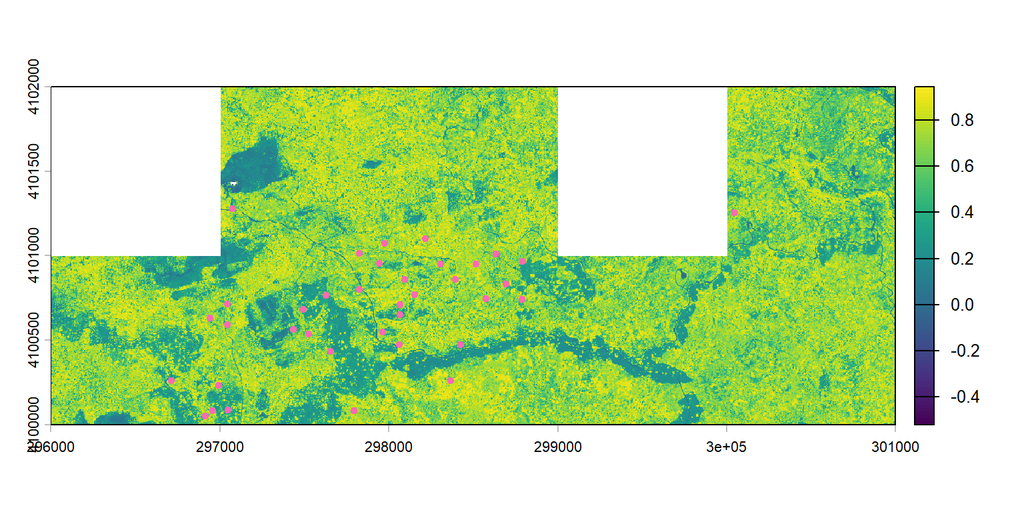

```r
plot(ndvi2019)

wf.SOAP <- fire.SOAP |>
  filter(methodTypeChoice=="fire-wildfire")
points(wf.SOAP$locationID_easting,
       wf.SOAP$locationID_northing,
       pch=20, col="hotpink")
```

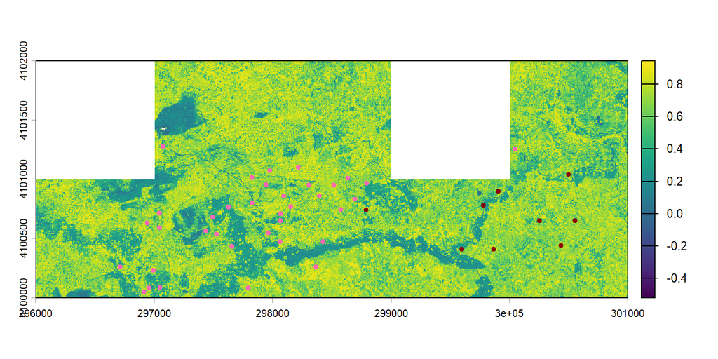

```r
plot(ndvi2019)

points(wf.SOAP$locationID_easting,
       wf.SOAP$locationID_northing,
       pch=20, col="hotpink")

cb.SOAP <- fire.SOAP |>
  filter(methodTypeChoice=="fire-controlledBurn")
points(cb.SOAP$locationID_easting,
       cb.SOAP$locationID_northing,
       pch=20, col="darkred")
```

We can utilize the `neonSiteMgmtEventData` package’s `createSIMPolygon()` function to create a polygon around the point locations for each event. The input to `createSIMPolygon()` is the output of `geoNEON::getLocTOS()`.

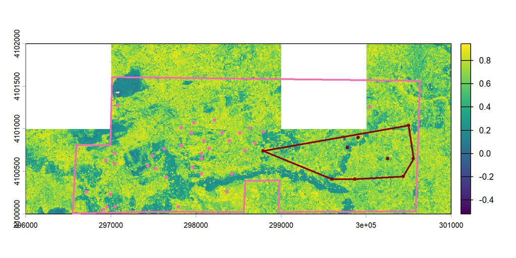

```r
# wildfire polygons
wf.SOAP.df <- fire.loc |>
  filter(siteID=="SOAP" & endDate<"2021-01-01" &
           eventType=="fire" &
           methodTypeChoice=="fire-wildfire")

wf.SOAP.polygon <- createSIMPolygon(df= wf.SOAP.df)

# transform the polygon from WGS84 (standard output) to utm zone 11N
# to match AOP tiles.
# coordinate reference system (crs) EPSG values can be searched for
# on https://spatialreference.org/ref/epsg/
wf.SOAP.polygon.utm <- st_transform(wf.SOAP.polygon$sfObjects[[1]],
                                    crs = 32611)

# controlled burn polygons
cb.SOAP.df <- fire.loc |>
  filter(siteID=="SOAP" & endDate<"2021-01-01" &
           eventType == "fire" &
           methodTypeChoice=="fire-controlledBurn")

cb.SOAP.polygon <- createSIMPolygon(df= cb.SOAP.df)

# transform the polygon from WGS84 (standard output) to utm zone 11N
# to match AOP tiles.
# coordinate reference system (crs) EPSG values can be searched for
# on https://spatialreference.org/ref/epsg/
cb.SOAP.polygon.utm <- st_transform(cb.SOAP.polygon$sfObjects[[1]],
                                    crs = 32611)


plot(ndvi2019)

points(wf.SOAP$locationID_easting,
       wf.SOAP$locationID_northing,
       pch=20, col="hotpink")

cb.SOAP <- fire.SOAP |>
  filter(methodTypeChoice=="fire-controlledBurn")
points(cb.SOAP$locationID_easting,
       cb.SOAP$locationID_northing,
       pch=20, col="darkred")

plot(sf::st_geometry(wf.SOAP.polygon.utm),
       border = "hotpink",
       lwd = 2.5,
       add = TRUE)

plot(sf::st_geometry(cb.SOAP.polygon.utm),
       border = "darkred",
       lwd = 2.5,
       add = TRUE)
```

We can see the wildfire polygon (light pink) include the entire site boundary since the site code “SOAP” was one of listed locationIDs.

The controlled burn polygon (dark red) was created as the smallest convex polygon around the listed locationID points.

The polygons provide our best estimate for the actual extent of the event across the site.

And now let’s look at the same locations in 2021.

```r
tiles2021 <- list.files(getwd(), pattern="NDVI.tif",
                        full.names=T, recursive=T)
tiles2021 <- grep("2021", tiles2021, value=T)

ndvi2021 <- rast(tiles2021[1])
for(i in 2:length(tiles2021)) {
  ndvii <- rast(tiles2021[i])
  ndvi2021 <- merge(ndvi2021, ndvii)
}
```

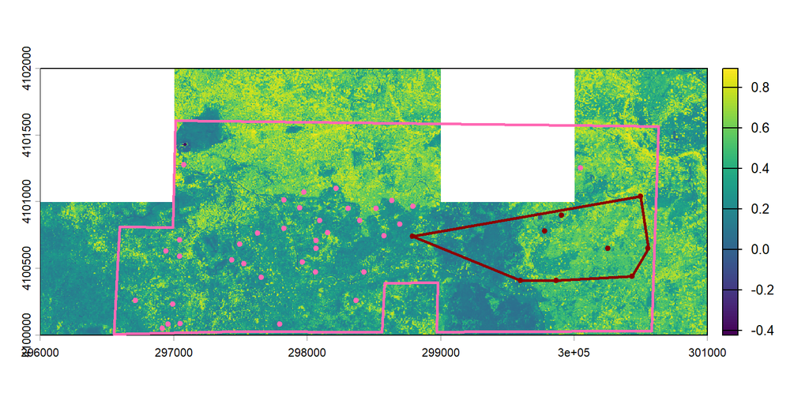

```r
plot(ndvi2021)

points(wf.SOAP$locationID_easting,
       wf.SOAP$locationID_northing,
       pch=20, col="hotpink")

points(cb.SOAP$locationID_easting,
       cb.SOAP$locationID_northing,
       pch=20, col="darkred")

plot(sf::st_geometry(wf.SOAP.polygon.utm),
       border = "hotpink",
       lwd = 2.5,
       add = TRUE)

plot(sf::st_geometry(cb.SOAP.polygon.utm),
       border = "darkred",
       lwd = 2.5,
       add = TRUE)
```

We can see a large region where NDVI is substantially lower in 2021 than 2019, matching the region where the wildfire was reported. Note there is some ambiguity in the region where the controlled burn was reported - it’s inside the overall wildfire polygon, but those specific points weren’t reported as burned by the wildfire. They are included because the site as a whole was reported.

In addition, we only downloaded the 8 NDVI tiles overlapping the sampling locations that were reported as affected by the fire; the entire AOP footprint is much larger than this. As noted above, NEON field staff report events at locations they visit, but in this case the fire was much larger than the NEON sampling region. The implications of this depend on your analytical goals. If you are studying fire at a regional level, you may focus primarily on the AOP data, whereas if you are primarily interested in plant community responses, you may want to focus on plant presence and percent cover plots, and the status of those specific plots.

```r
# export the wildfire polygons as kmls
writeExportFile(sfList = wf.SOAP.polygon$sfObjects,
                outDir = getwd(),
                outType = "kml")

# export the controlled burns polygons as shapefiles
writeExportFile(sfList = cb.SOAP.polygon$sfObjects,
                outDir = getwd(),
                outType = "shapefile")
```

For more information and examples using the `createSIMPolygon()` function please see the vignette associated with the package.

```
remotes::install_github("NEONScience/neonSiteMgmtEventData", build_vignettes = TRUE, force = T)
browseVignettes("neonSiteMgmtEventData")
```